# Final Project Kyle Phaymany

2025-12-07

#### Term Project Description

This document is a final project for the UCSD Course BILD 5. My project builds upon the study referenced below. I have proposed a potential follow-up experiment to extend the study’s findings. The project utilizes simulated data, structured and analyzed as if collected from a real experiment. While the outcomes do not provide scientific evidence, they showcase my skills in formulating and addressing relevant biological questions through statistics, experimental design, and programming.

#### Article Citation

“Relationship between oral health and physical frailty in patients with cardiovascular disease”

#### Research Question

Will providing tooth implants or dentures to Cardiovascular Disease patients improve their grip strength?

#### Null Hypothesis

Null: Mean of delta of grip strength (kg) = theta

There is no change in the mean grip strength of Cardiovascular Disease patients before and 6 months after obtaining tooth implants or dentures.

#### Alternative Hypothesis

Alt: Mean of delta of grip strength (kg)!= theta

There is a change in the mean grip strength of Cardiovascular Disease patients before and 6 months after obtaining tooth implants or dentures.

#### Test Performed

Paired T-test

#### Import and Tidy the Data

```
## 'data.frame':    400 obs. of  4 variables:
##  $ X           : int  1 2 3 4 5 6 7 8 9 10 ...
##  $ After6months: num  25 44 29.7 36.8 28.5 ...
##  $ Before      : num  18.3 36.7 20.8 31 24 ...
##  $ delta       : num  6.69 7.38 8.86 5.82 4.46 ...
```

#### Exploratory Data Analysis

I want to check the normality of the data to make sure its normally distributed. I’m using a paired test, so I should be checking the normality of the difference of values (delta) between After 6 months and before. That means I’ll plot a histogram of the delta values to visually check for any skews or outliers, then perform a ks.test to check the p value.

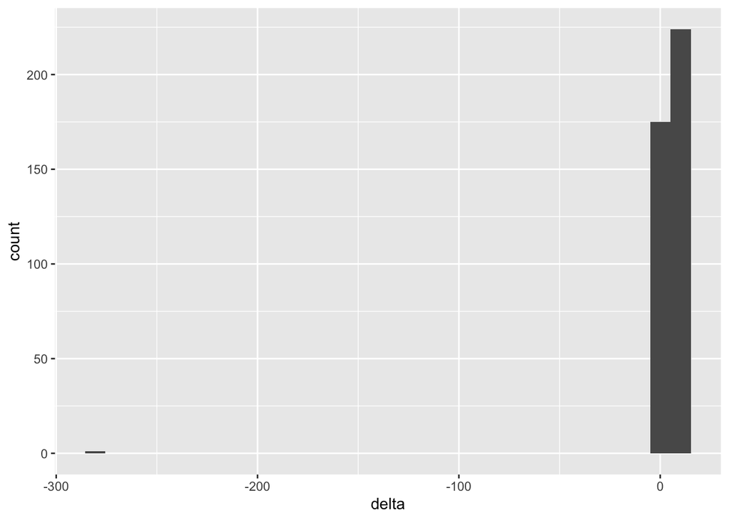

```r
histo1<- ggplot(TIDY_DF, aes(x=delta))+
  geom_histogram()
histo1
```

```r
ks.test(TIDY_DF$delta, pnorm, mean(TIDY_DF$delta), sd(TIDY_DF$delta))
```

```
##
##  Asymptotic one-sample Kolmogorov-Smirnov test
##
## data:  TIDY_DF$delta
## D = 0.41288, p-value < 2.2e-16
## alternative hypothesis: two-sided
```

#### Description of Current Data and Plan for Fixes if Needed

Checking the histogram of my tidy data, it shows an outlier to the left of the data. We can assume that this outlier making my data appear not normally distributed. The ks.test gives a p value of 2.2e-16. The p value is below 0.05, which fully confirms that my data is not normally distributed. To fix this, I will get rid of the outlier data point and test the normality again.

#### Correct Data Issues and Build Final Data Table.

I will find and get rid of the datapoint outlier that is skewing my data.

```
## 'data.frame':    399 obs. of  4 variables:
##  $ X           : int  1 2 3 4 5 6 7 8 9 10 ...
##  $ After6months: num  25 44 29.7 36.8 28.5 ...
##  $ Before      : num  18.3 36.7 20.8 31 24 ...
##  $ delta       : num  6.69 7.38 8.86 5.82 4.46 ...
```

#### Demonstrate That Your New Data Fit the Assmuptions of the Model

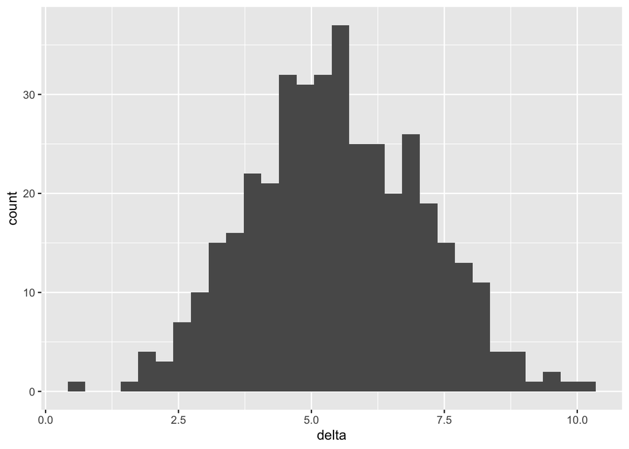

```r
q4<-ks.test(Corrected_TIDY_DF$delta, pnorm, mean(Corrected_TIDY_DF$delta), sd(Corrected_TIDY_DF$delta))
q4
```

```
##
##  Asymptotic one-sample Kolmogorov-Smirnov test
##
## data:  Corrected_TIDY_DF$delta
## D = 0.030245, p-value = 0.8588
## alternative hypothesis: two-sided
```

#### Test the Null Hypothesis of Your Research Question

```r
q5<-t.test(x=Corrected_TIDY_DF$After6months, y=Corrected_TIDY_DF$Before, paired = TRUE)
q5
```

```
##
##  Paired t-test
##
## data:  Corrected_TIDY_DF$After6months and Corrected_TIDY_DF$Before
## t = 67.082, df = 398, p-value < 2.2e-16
## alternative hypothesis: true mean difference is not equal to 0
## 95 percent confidence interval:
##  5.312055 5.632810
## sample estimates:
## mean difference
##        5.472433
```

#### Build the Figure That Best Tells the Story of Your Model

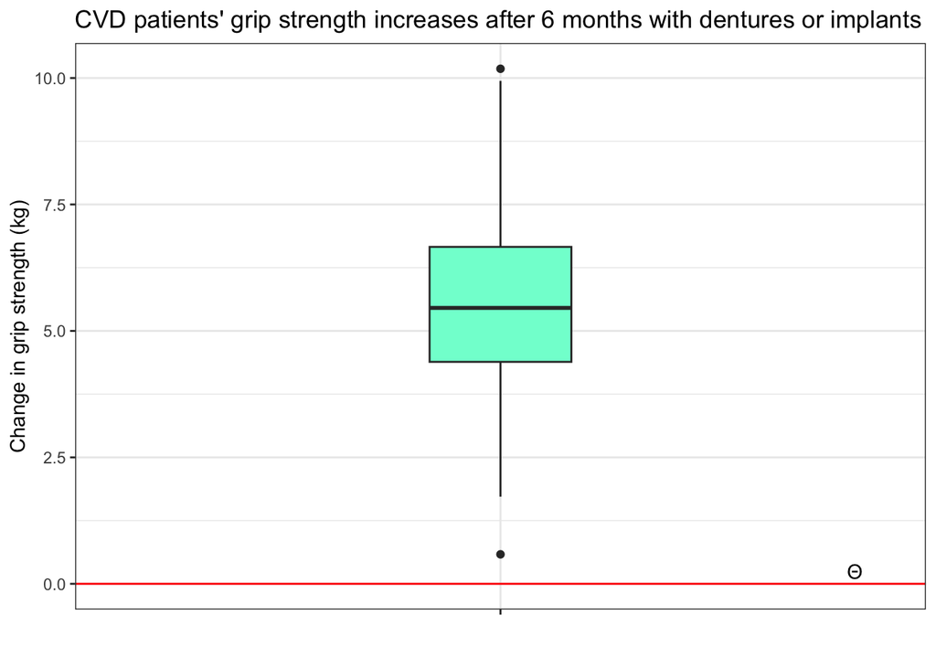

#### Figure Caption

My figure is a boxplot that displays the delta values of Cardiovascular disease patients’ grip strength before and after receiving tooth implants/dentures for 6 months. The red line below the figure represents theta which is at 0. We reject the null because the paired t-test comes back with a p-value of less than 2.2e-16. This also tells us that the probability of observing a mean that is 67.082 or more extreme standard errors away from theta is less than 2.2e-16. We are 95% confident that the true value increase in grip strength lies between 5.312055 kg and 5.632810 kg. Our degrees of freedom is 398 because I removed one patient’s data shrinking the sample size from 400 to 399, and calculating the mean of the delta costs one degree of freedom. The mean grip strength increased by 5.472 kg 6 months after tooth plants/dentures. Overall, these results tells us that patients with CVD can gain or recover around 5.472 kg of grip strength through tooth implants or dentures after a period of 6 months. In the context of the original paper, this implies that improving oral health can improve physical strength in CVD patients after a period of time.